# Comments for MEDB 5501, Week 12

## Nonparametric tests

- Most developed in the 1950s.
- A test that does not rely on distributional assumptions
  - “Distribution free test” is more mathematically precise
- Important!! Other assumptions will remain
  - Especially independence
- Nonparametric implies no population parameter
  - Mathematical form of hypotheses is tricky

## The probability basis for ranking

You randomly draw three balls from an urn containing balls numbered 1 through 9. What are the chances that you draw the highest three balls (7, 8, and 9)?

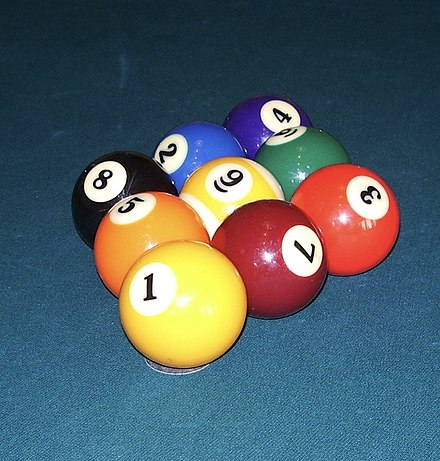

## List all the possible outcomes.

```
1,2,3  1,2,4  1,2,5  1,2,6  1,2,7  1,2,8  1,2,9
1,3,4  1,3,5  1,3,6  1,3,7  1,3,8  1,3,9  1,4,5
1,4,6  1,4,7  1,4,8  1,4,9  1,5,6  1,5,7  1,5,8
1,5,9  1,6,7  1,6,8  1,6,9  1,7,8  1,7,9  1,8,9
2,3,4  2,3,5  2,3,6  2,3,7  2,3,8  2,3,9  2,4,5
2,4,6  2,4,7  2,4,8  2,4,9  2,5,6  2,5,7  2,5,8
2,5,9  2,6,7  2,6,8  2,6,9  2,7,8  2,7,9  2,8,9
3,4,5  3,4,6  3,4,7  3,4,8  3,4,9  3,5,6  3,5,7
3,5,8  3,5,9  3,6,7  3,6,8  3,6,9  3,7,8  3,7,9
3,8,9  4,5,6  4,5,7  4,5,8  4,5,9  4,6,7  4,6,8
4,6,9  4,7,8  4,7,9  4,8,9  5,6,7  5,6,8  5,6,9
5,7,8  5,7,9  5,8,9  6,7,8  6,7,9  6,8,9  7,8,9
```

## Artificial data set

```
 X group value
 1     X 14976
 2     X 44415
 3     X 46286
 4     Y  4855
 5     Y     0
 6     Y   486
 7     Y  1803
 8     Y    86
 9     Y  1159
```

## Test statistic, $\Sigma R(X_i)$, 1 of 2

```
 6  1,2,3
 7  1,2,4
 8  1,2,5  1,3,4
 9  1,2,6  1,3,5  2,3,4
10  1,2,7  1,3,6  1,4,5  2,3,5
11  1,2,8  1,3,7  1,4,6  2,3,6  2,4,5
12  1,2,9  1,3,8  1,4,7  1,5,6  2,3,7  2,4,6  3,4,5
13  1,3,9  1,4,8  1,5,7  2,3,8  2,4,7  2,5,6  3,4,6
14  1,4,9  1,5,8  1,6,7  2,3,9  2,4,8  2,5,7  3,4,7  3,5,6
15  1,5,9  1,6,8  2,4,9  2,5,8  2,6,7  3,4,8  3,5,7  4,5,6
```

## Test statistic, $\Sigma R(X_i)$, 2 of 2

```
16  1,6,9  1,7,8  2,5,9  2,6,8  3,4,9  3,5,8  3,6,7  4,5,7
17  1,7,9  2,6,9  2,7,8  3,5,9  3,6,8  4,5,8  4,6,7
18  1,8,9  2,7,9  3,6,9  3,7,8  4,5,9  4,6,8  5,6,7
19  2,8,9  3,7,9  4,6,9  4,7,8  5,6,8
20  3,8,9  4,7,9  5,6,9  5,7,8
21  4,8,9  5,7,9  6,7,8
22  5,8,9  6,7,9
23  6,8,9
24  7,8,9
```

## Alternate calculation, $P[X>Y]$

$$\begin{matrix} & X_{1} & X_{2} & X_{3} \\ Y_{1} & 0\ or\ 1 & 0\ or\ 1 & 0\ or\ 1 \\ Y_{2} & 0\ or\ 1 & 0\ or\ 1 & 0\ or\ 1 \\ Y_{3} & 0\ or\ 1 & 0\ or\ 1 & 0\ or\ 1 \\ Y_{4} & 0\ or\ 1 & 0\ or\ 1 & 0\ or\ 1 \\ Y_{5} & 0\ or\ 1 & 0\ or\ 1 & 0\ or\ 1 \\ Y_{6} & 0\ or\ 1 & 0\ or\ 1 & 0\ or\ 1 \end{matrix}$$

## Break #1

- What have you learned
  - The probability basis for many nonparametric tests
- What is coming next
  - A formal description of the Mann-Whitney-Wilcoxon test

## Mann-Whitney-Wilcoxon (MWW) test, 1 of 2

- Also known as Wilcoxon-Mann-Whitney test
- Two independent samples
  - $X_1,X_2,...,X_n$
  - $Y_1,Y_2,...,Y_m$
  - n, m do not have to be equal

## What hypothesis are you testing

- Tricky because non-parametric means no parameter
  - $H_0:\ P[X>Y] = 0.5$ or
  - $H_0:\ X_{0.5}=Y_{0.5}$ (controversial)
- Alternative formulation: shifted distributions
  - $P[X \le t]=P[Y - \Delta \le t]$
  - $H_0:\ \Delta=0$

## Assumptions of the MWW test

- Observations are independent
  - Within each sample
  - Between samples
- Distributions identical when $H_0$ is true, or
- Distribution of Y is uniformly shifted from the distribution of X
  - Unequal variances is a violation of either of these assumptions

## How to handle ties, 1 of 4

```
  X group value rank
1 1     X  4855    ?
2 2     X 44415    8
3 3     X 46286    9
4 4     Y  4855    ?
5 5     Y     0    1
6 6     Y   486    3
7 7     Y  4855    ?
8 8     Y    86    2
9 9     Y  1159    4
```

## How to handle ties, 2 of 4

```
  X group value rank
1 1     X  4855    6
2 2     X 44415    8
3 3     X 46286    9
4 4     Y  4855    6
5 5     Y     0    1
6 6     Y   486    3
7 7     Y  4855    6
8 8     Y    86    2
9 9     Y  1159    4
```

## How to handle ties, 3 of 4

```
 6  1,2,3
 7  1,2,4
 8  1,3,4
 9  1,2,6  1,2,6  1,2,6  2,3,4
10  1,3,6  1,3,6  1,3,6
11  1,2,8  1,4,6  1,4,6  1,4,6  2,3,6  2,3,6  2,3,6
12  1,2,9  1,3,8  2,4,6  2,4,6  2,4,6
13  1,3,9  1,4,8  1,6,6  1,6,6  1,6,6  2,3,8  3,4,6  3,4,6  3,4,6
14  1,4,9  2,3,9  2,4,8  2,6,6  2,6,6  2,6,6
15  1,6,8  1,6,8  1,6,8  2,4,9  3,4,8  3,6,6  3,6,6  3,6,6
```

## How to handle ties, 4 of 4

```
16  1,6,9  1,6,9  1,6,9  2,6,8  2,6,8  2,6,8  3,4,9  4,6,6  4,6,6  4,6,6
17  2,6,9  2,6,9  2,6,9  3,6,8  3,6,8  3,6,8
18  1,8,9  3,6,9  3,6,9  3,6,9  4,6,8  4,6,8  4,6,8  6,6,6
19  2,8,9  4,6,9  4,6,9  4,6,9
20  3,8,9  6,6,8  6,6,8  6,6,8
21  4,8,9  6,6,9  6,6,9  6,6,9
22
23  6,8,9  6,8,9  6,8,9
24
```

## Break #2

- What have you learned
  - A formal description of the Mann-Whitney-Wilcoxon test
- What is coming next
  - Tables, exact tests, Monte Carlo tests, and normal approximation

## MWW test using tables

[figure not shown]

::: notes

:::

## MWW test using an exact test

```
# r code to list all possible test values for
# MWW test with n=3, m=6

n <- 3
m <- 6
T <- rep(NA, (n+m)*(n+m-1)*(n+m-2)/6)
r <- 1:(n+m)
u <- 0

for (i in 1:(n+m-2)) {
  for (j in (i+1):(n+m-1)) {
    for (k in (j+1):(n+m)) {
      u <- u+1
      T[u] <- r[i]+r[j]+r[k]
    }
  }
}
```

## MWW test using a Monte Carlo approximation

```
# r code to compute a Monte Carlo approximation
# for the Mann-Whitney-Wilcoxon test with n=3, m=6

n <- 3
m <- 6
reps <- 10000
T <- rep(NA, reps)
r <- 1:N
u <- 0

for (i in 1:reps) {
  T[i] <- sum(sample(r, 3))
}
```

## MWW test using a normal approximation

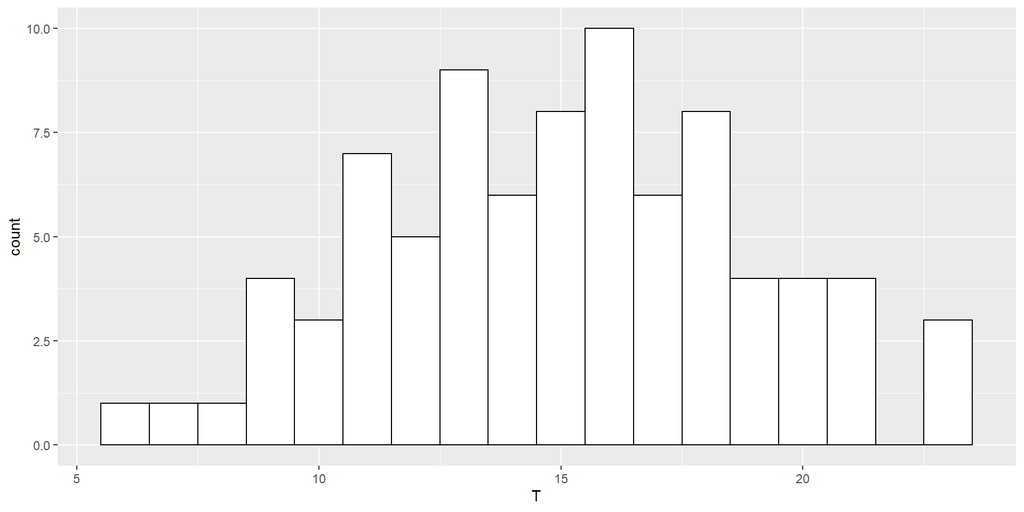

## When should you use MWW test?

- Small sample sizes and/or
- Non-normality and/or
- Ordinal outcome variable

## Which MMW test?

- Tables: never!
- Exact test: small (n+m < 100) sample sizes
- Monte Carlo approximation: moderate (100 < n+m < 1 million) sample sizes
- Normal approximation: moderate or large (n+m > 1 million) sample sizes
  - The cutoffs for small, moderate, and large are my interpretations only.

## Example: FEV data, 1 of 2

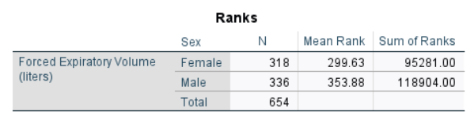

## Example: FEV data, 2 of 2

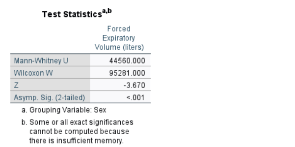

## Common nonparametric tests

- Mann-Whitney-Wilcoxon vs. independent samples t-test
- Kruskal-Wallis test vs. ANOVA
- Wilcoxon signed rank test vs. paired t-test
- Friedman test vs. randomized block design

Note: in this class, homework, quizzes, and final exam will only cover the MWW test.

## Criticisms of nonparametric tests

- Less power than parametric tests
  - Only a small loss in power
  - Only when normality assumption is satisfied
- Difficult to produce confidence intervals
- Difficult to perform risk adjustments
- Limited extensions to more complex settings

## Criticisms of parametric tests

- Perform poorly when data skewed, or has outliers
- Cannot handle ordinal data

## Decision algorithm

- Decide prior to data collection
- Review assumptions and then decide